# PART II: ANALYSIS OF PROSPER LOAN DATA FROM 2005 TO 2014

# What percentage of loans are given to borrower's whose income source are not verifiable over the years?

Income_verifiable feature having a True or False value is not evenly distributed over the years. It is pertinent to say that borrower's with verifiable income source have a higher possibility of getting a loan. Non verified borrower's obtained the highest loan in 2013 with only 1.971% of the total loan that year compared to 28.80% given to verified borrower's.

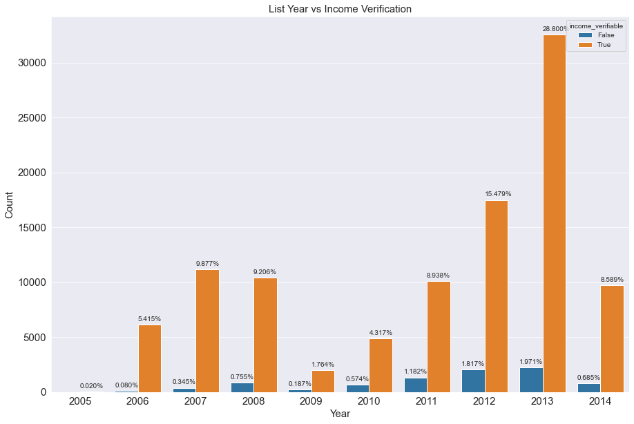

# How is the term of the loan distributed over the list_year?

The medium term loans apparently have the most occurrence in all the years, with the short term loans most occurence being in 2012. The long term loan occurred most in 2013 with 11.950%. A further dive int this dataset using seaborn facetgrid will throw more light.

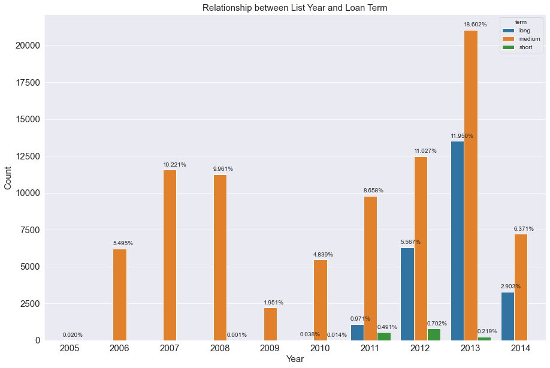

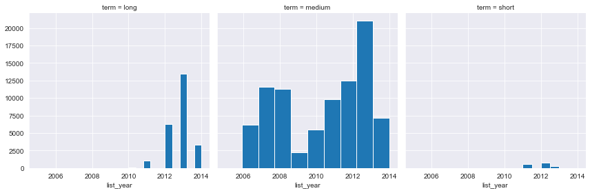

# How is loan payment made in relation to loan amount and term of loan?

Having established a strong positive correlation between loan amount and monthly payment, adding an extra feature, term, to it shows another relationship. The is also a strong positive correlation between these features and aside that, it is observed that the short term loans have higher payments, followed by the medium term and long term loans. This might be as a result of the time interval needed to payup the loan amount, that is, short term loans having the time frame of 12 months requires a higher payment in order to complete it within the time frame. But long term loan with 60 months payment period will be paid in smaller bits. From the plot, it is seen also that the maximum short term loan amount is about 25,000 dollars.

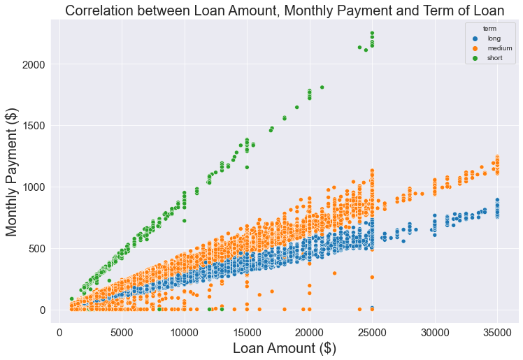

# Does employment_status have any effect on loan_amount and monthly_payment?

It appears Employed borrower's get most of the loans, as it is the most in the data points.

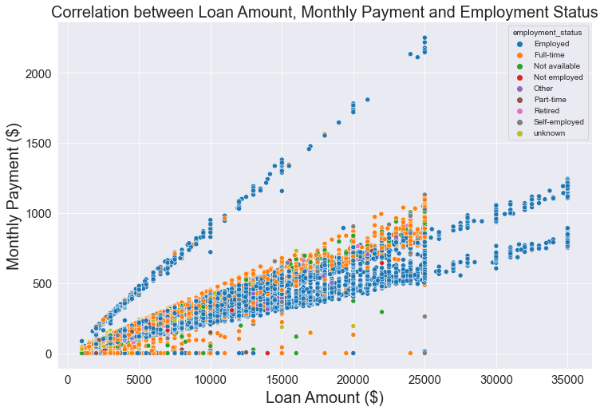

# How does being a home_owner status affect loan_amount and monthly_payment?

The data points appears to be evenly distributed, though there is a slight difference as observed during univariate exploration. The home_owner status does not really contribute much, or probably have no effect on the loan being granted or not.

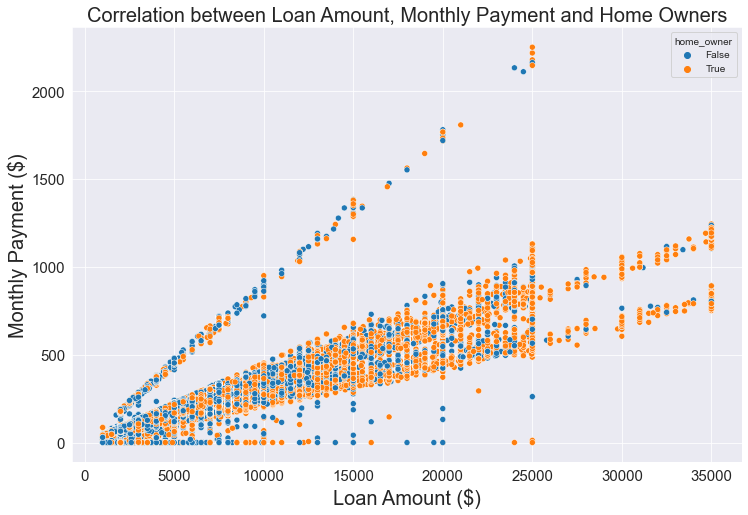

# Loan distribution and payment over the list year.

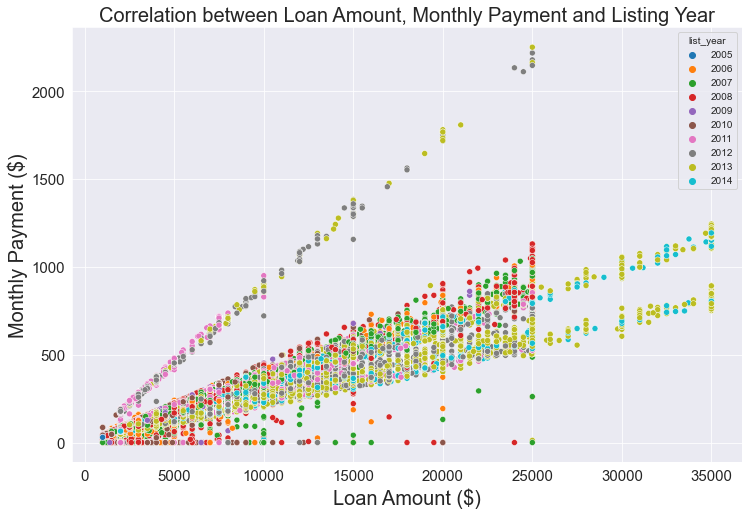